# TSRethinking11 Cointegration

Wayne Zhang

10/9/2021

## 0.1 Define Cointegration

: $Y_t$ and $X_t$ are non-stationary variables. If there exists $\beta$ such that $Y_t - \beta X_t = u_t$ is stationary, then we say that $Y_t$ and $X_t$ are cointegrated.

:

- If $Y_t\sim I(d), X_t\sim I(b)$, then we say $u_t\sim CI(d, b)$;
- If $u_t$ is $I(1)$, integrated with order 1(after first difference the series will be stationary), then $Y_t$ and $X_t$ are not cointegrated; meanwhile, regressing $Y_t$ on $X_t$ will yield a spurious result.

### 0.1.1 Common Trends

Decomposition variables:

$$Y_t = \mu_{y, t} + v_{y, t}\quad X_t =
\mu_{x, t} + v_{x, t}$$

where $\mu_{i, t}$ is the stochastic trend part, and $v_{i, t}$ is the stationary component.

Assume $\beta_y \mu_{y, t} + \beta_x \mu_{x, t} = 0$, then we have $\beta_y Y_t + \beta_x X_t = \beta_y v_{y, t} + \beta_x v_{x, t}$ are stationary. Thus, $Y_t$ and $X_t$ are cointegration.

```r
library(vars)
library(tidyverse)
library(xts)
library(zoo)
library(FinCal)

gold_ores <- fred("PCU2122212122210", "1985-06-01", "2017-12-01")[, -1]
silver <- fred("WPU159402", "1985-06-01", "2017-12-01")[, -1]
```

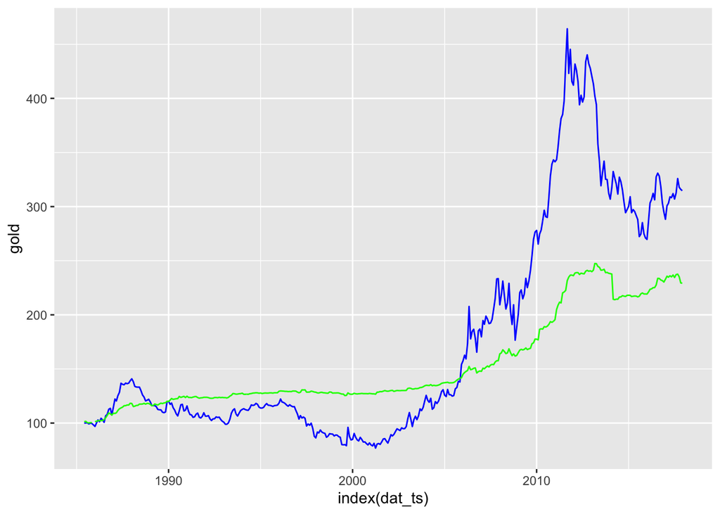

```r
dat_ts <- xts(cbind(gold_ores$price, silver$price), order.by = silver$date)
colnames(dat_ts) <- c("gold", "silver")
ggplot(data = dat_ts) +
    geom_line(aes(x = index(dat_ts), y = gold), color = "blue") +
    geom_line(aes(x = index(dat_ts), y = silver), color = "green")
```

```r
# unit root tests (augmented Dickey-Fuller test)
adft1 <- ur.df(dat_ts$gold, type = "trend", selectlags = c("BIC"))
summary(adft1)
```

```
##
## ###############################################
## # Augmented Dickey-Fuller Test Unit Root Test #
## ###############################################
##
## Test regression trend
##
##
## Call:
## lm(formula = z.diff ~ z.lag.1 + 1 + tt + z.diff.lag)
##
## Residuals:
##     Min      1Q  Median      3Q     Max
## -40.134  -3.048  -0.325   2.555  35.321
##
## Coefficients:
##              Estimate Std. Error t value Pr(>|t|)
## (Intercept)  0.454546   0.916067   0.496    0.620
## z.lag.1     -0.010351   0.006876  -1.505    0.133
## tt           0.009745   0.006185   1.576    0.116
## z.diff.lag   0.006454   0.050908   0.127    0.899
##
## Residual standard error: 8.606 on 385 degrees of freedom
## Multiple R-squared:  0.006925,   Adjusted R-squared:  -0.0008134
## F-statistic: 0.8949 on 3 and 385 DF,  p-value: 0.4438
##
##
## Value of test-statistic is: -1.5054 1.4211 1.3405
##
## Critical values for test statistics:
##       1pct  5pct 10pct
## tau3 -3.98 -3.42 -3.13
## phi2  6.15  4.71  4.05
## phi3  8.34  6.30  5.36
```

```r
# the null of a unit root of test statistic is -1.5054
# the critical values are -3.98 -3.42 -3.13 for the 1%, 5% and 10% significance levels
# Thus, we cannot reject the null hypothesis; F statistic tells us that we cannot reject the trend;

adft2 <- ur.df(dat_ts$gold, type = "drift", selectlags = c("BIC"))
summary(adft2) # there is drift
```

```
##
## ###############################################
## # Augmented Dickey-Fuller Test Unit Root Test #
## ###############################################
##
## Test regression drift
##
##
## Call:
## lm(formula = z.diff ~ z.lag.1 + 1 + z.diff.lag)
##
## Residuals:
##     Min      1Q  Median      3Q     Max
## -41.336  -3.115  -0.630   2.873  34.622
##
## Coefficients:
##              Estimate Std. Error t value Pr(>|t|)
## (Intercept)  0.887014   0.875660   1.013    0.312
## z.lag.1     -0.001925   0.004331  -0.445    0.657
## z.diff.lag   0.004490   0.050990   0.088    0.930
##
## Residual standard error: 8.622 on 386 degrees of freedom
## Multiple R-squared:  0.000521,   Adjusted R-squared:  -0.004658
## F-statistic: 0.1006 on 2 and 386 DF,  p-value: 0.9043
##
##
## Value of test-statistic is: -0.4445 0.8868
##
## Critical values for test statistics:
##       1pct  5pct 10pct
## tau2 -3.44 -2.87 -2.57
## phi1  6.47  4.61  3.79
```

```r
adft3 <- ur.df(dat_ts$gold, type = "none", selectlags = c("BIC"))
summary(adft3)
```

```
##
## ###############################################
## # Augmented Dickey-Fuller Test Unit Root Test #
## ###############################################
##
## Test regression none
##
##
## Call:
## lm(formula = z.diff ~ z.lag.1 - 1 + z.diff.lag)
##
## Residuals:
##     Min      1Q  Median      3Q     Max
## -42.176  -2.652  -0.197   3.096  34.014
##
## Coefficients:
##            Estimate Std. Error t value Pr(>|t|)
## z.lag.1    0.001873   0.002167   0.865    0.388
## z.diff.lag 0.003318   0.050979   0.065    0.948
##
## Residual standard error: 8.623 on 387 degrees of freedom
## Multiple R-squared:  0.001979,   Adjusted R-squared:  -0.003179
## F-statistic: 0.3837 on 2 and 387 DF,  p-value: 0.6816
##
##
## Value of test-statistic is: 0.8646
##
## Critical values for test statistics:
##       1pct  5pct 10pct
## tau1 -2.58 -1.95 -1.62
```

```r
adft4 <- ur.df(na.omit(diff(dat_ts$gold)), selectlags = c("BIC"))
summary(adft4) # this test is to check it is I(2) time series or not;
```

```
##
## ###############################################
## # Augmented Dickey-Fuller Test Unit Root Test #
## ###############################################
##
## Test regression none
##
##
## Call:
## lm(formula = z.diff ~ z.lag.1 - 1 + z.diff.lag)
##
## Residuals:
##     Min      1Q  Median      3Q     Max
## -39.961  -2.319  -0.014   3.294  34.864
##
## Coefficients:
##            Estimate Std. Error t value Pr(>|t|)
## z.lag.1    -1.03499    0.07167 -14.442   <2e-16 ***
## z.diff.lag  0.04246    0.05086   0.835    0.404
## ---
## Signif. codes:  0 '***' 0.001 '**' 0.01 '*' 0.05 '.' 0.1 ' ' 1
##
## Residual standard error: 8.634 on 386 degrees of freedom
## Multiple R-squared:  0.4973, Adjusted R-squared:  0.4947
## F-statistic: 190.9 on 2 and 386 DF,  p-value: < 2.2e-16
##
##
## Value of test-statistic is: -14.442
##
## Critical values for test statistics:
##       1pct  5pct 10pct
## tau1 -2.58 -1.95 -1.62
```

```r
# the test result tells us it does not I(2)

# we can do the same thing for silver variable
```

## 0.2 Error Correction Models

## 0.3 Deriving a measure of the real equilibrium exchange rate

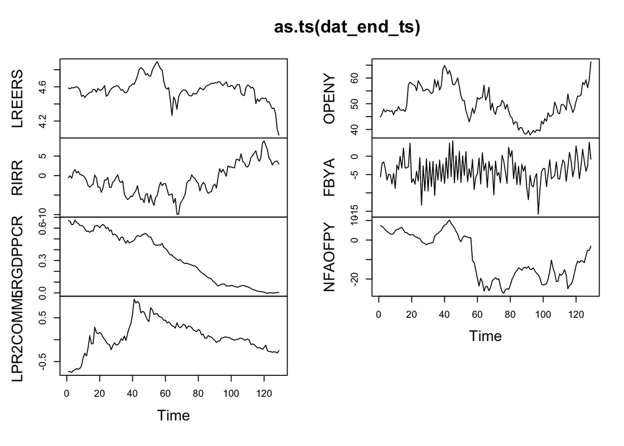

```r
dat <- read.csv(file = "/Users/waynezhang/Library/CloudStorage/OneDrive-UW-Madison/IOS-WIN/Econometric method/EMLearn/Topics/Undo/Time_Series/LectureNotes/T10-coint/Mac_Ric.csv")
dat_end_ts <- xts(dat[, c("LREERS", "RIRR", "LRGDPPCR", "LPR2COMM5",
    "OPENY", "FBYA", "NFAOFPY")], order.by = anytime::anydate(dat[, 1]))
# LREERS: the logarithm of real effective exchange rate
# RIRR: real interest rate relative to trading partners
# LRGDPPCR: logarithm of real GDP per capita relative to trading partners
# LPR2COMM5: real commodity prices;
# OPENY: openness (ratio to GDP of exports and imports);
# FBYA: ratio of fiscal balance to GDP;
# NFAOFPY: the ratio to GDP of net foreign assets of the banking system
plot(as.ts(dat_end_ts))
```

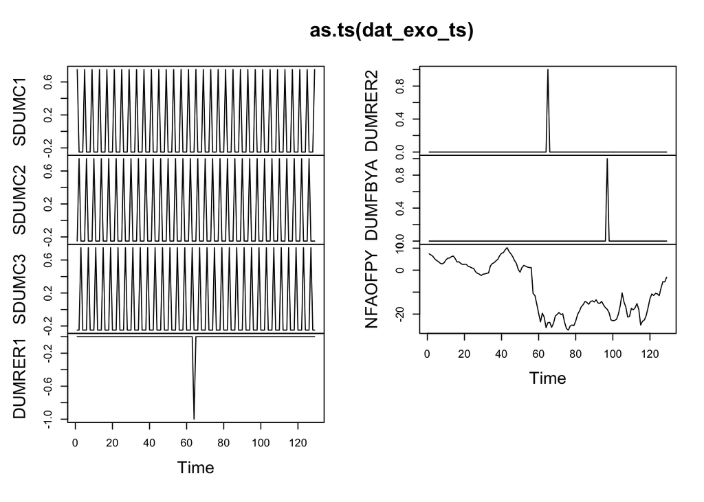

```r
# exodogenous variable
dat_exo_ts <- xts(dat[, c("SDUMC1", "SDUMC2", "SDUMC3", "DUMRER1",
    "DUMRER2", "DUMFBYA", "NFAOFPY")], order.by = anytime::anydate(dat[, 1]))
plot(as.ts(dat_exo_ts))
```

### 0.3.1 Estimate the model

```r
dat.VAR <- cbind(dat$LREERS, dat$RIRR, dat$LRGDPPCR, dat$LPR2COMM5,
    dat$OPENY, dat$FBYA, dat$NFAOFPY)
colnames(dat.VAR) <- c("LREERS", "RIRR", "LRGDPPCR", "LPR2COMM5",
    "OPENY", "FBYA", "NFAOFPY")
dat.EXO <- cbind(dat$SDUMC1, dat$SDUMC2, dat$SDUMC3, dat$DUMRER1,
    dat$DUMRER2, dat$DUMFBYA, dat$DUMNFAOFPY)
colnames(dat.EXO) <- c("SDUMC1", "SDUMC2", "SDUMC3", "DUMRER1",
    "DUMRER2", "DUMFBYA", "NFAOFPY")

VAR.est <- VAR(dat.VAR, p = 4, type = "const", season = NULL,
    exog = dat.EXO)
summary(VAR.est)
```

```
##
## VAR Estimation Results:
## =========================
## Endogenous variables: LREERS, RIRR, LRGDPPCR, LPR2COMM5, OPENY, FBYA, NFAOFPY
## Deterministic variables: const
## Sample size: 125
## Log Likelihood: -117.888
## Roots of the characteristic polynomial:
## 1.015 1.015 0.9641 0.8839 0.8822 0.8582 0.8582 0.8444 0.8444 0.799 0.799 0.7556 0.7556 0.7401 0.7401 0.6946 0.6946 0.615 0.615 0.5544 0.5544 0.5321 0.5321 0.5174 0.4191 0.2592 0.2592 0.1678
## Call:
## VAR(y = dat.VAR, p = 4, type = "const", exogen = dat.EXO)
##
##
## Estimation results for equation LREERS:
## =======================================
## LREERS = LREERS.l1 + RIRR.l1 + LRGDPPCR.l1 + LPR2COMM5.l1 + OPENY.l1 + FBYA.l1 + NFAOFPY.l1 + LREERS.l2 + RIRR.l2 + LRGDPPCR.l2 + LPR2COMM5.l2 + OPENY.l2 + FBYA.l2 + NFAOFPY.l2 + LREERS.l3 + RIRR.l3 + LRGDPPCR.l3 + LPR2COMM5.l3 + OPENY.l3 + FBYA.l3 + NFAOFPY.l3 + LREERS.l4 + RIRR.l4 + LRGDPPCR.l4…
##
##                Estimate Std. Error t value Pr(>|t|)
## LREERS.l1     1.176e+00  1.264e-01   9.299 9.03e-15 ***
## RIRR.l1      -4.128e-03  3.814e-03  -1.082 0.282084
## LRGDPPCR.l1   1.847e-01  3.698e-01   0.499 0.618685
## LPR2COMM5.l1  6.426e-02  5.352e-02   1.201 0.233096
## OPENY.l1      4.056e-05  2.302e-03   0.018 0.985983
## FBYA.l1       1.554e-03  1.621e-03   0.959 0.340272
## NFAOFPY.l1   -6.449e-03  2.569e-03  -2.510 0.013863 *
## LREERS.l2    -1.708e-01  1.711e-01  -0.998 0.320942
## RIRR.l2      -1.640e-03  5.157e-03  -0.318 0.751196
## LRGDPPCR.l2  -3.499e-02  4.905e-01  -0.071 0.943291
## LPR2COMM5.l2  4.321e-02  6.822e-02   0.633 0.528119
## OPENY.l2     -2.781e-03  2.848e-03  -0.976 0.331505
## FBYA.l2      -1.992e-03  1.629e-03  -1.223 0.224695
## NFAOFPY.l2    6.500e-03  3.924e-03   1.657 0.101131
## LREERS.l3     1.568e-01  1.623e-01   0.966 0.336660
## RIRR.l3       4.297e-03  5.076e-03   0.847 0.399454
## LRGDPPCR.l3  -4.541e-01  4.613e-01  -0.984 0.327550
## LPR2COMM5.l3  1.130e-02  6.767e-02   0.167 0.867755
## OPENY.l3      6.635e-04  2.895e-03   0.229 0.819265
## FBYA.l3      -8.705e-04  1.590e-03  -0.547 0.585417
## NFAOFPY.l3    1.828e-04  4.096e-03   0.045 0.964508
## LREERS.l4    -1.940e-01  1.190e-01  -1.631 0.106520
```

[output cut: 336 more lines]

```
## LRGDPPCR   0.003159
## LPR2COMM5  0.034119
## OPENY     -0.384976
## FBYA      -0.510952
## NFAOFPY    3.435657
##
## Correlation matrix of residuals:
##              LREERS      RIRR LRGDPPCR LPR2COMM5    OPENY     FBYA  NFAOFPY
## LREERS     1.000000 -0.119840 -0.03652  0.008195 -0.44155 -0.12016  0.46682
## RIRR      -0.119840  1.000000  0.36897 -0.009459  0.17742  0.03183  0.01767
## LRGDPPCR  -0.036522  0.368967  1.00000  0.197787  0.18315  0.04398  0.12954
## LPR2COMM5  0.008195 -0.009459  0.19779  1.000000  0.17131  0.10658  0.21471
## OPENY     -0.441548  0.177421  0.18315  0.171310  1.00000 -0.04247 -0.08915
## FBYA      -0.120161  0.031827  0.04398  0.106575 -0.04247  1.00000 -0.11876
## NFAOFPY    0.466817  0.017667  0.12954  0.214715 -0.08915 -0.11876  1.00000
```

```r
# VAR.est <- VAR(dat_end_ts, p = 4, type = "const", season = NULL,
#     exog = dat_exo_ts)
# summary(VAR.est)
```

#### 0.3.1.1 Test cointegration

Now to ensure that the variables are cointegrated we need to run the Johansen test. To perform the trace test we use the command:

```r
H1.trace <- ca.jo(dat.VAR, ecdet = c("const"), type = "trace",
    K = 4, season = NULL, dumvar = dat.EXO)
summary(H1.trace)
```

```
##
## ######################
## # Johansen-Procedure #
## ######################
##
## Test type: trace statistic , without linear trend and constant in cointegration
##
## Eigenvalues (lambda):
## [1] 3.247102e-01 2.010480e-01 1.678423e-01 1.370459e-01 1.024100e-01
## [6] 5.126687e-02 3.871036e-02 2.339826e-16
##
## Values of teststatistic and critical values of test:
##
##            test  10pct   5pct   1pct
## r <= 6 |   4.93   7.52   9.24  12.97
## r <= 5 |  11.51  17.85  19.96  24.60
## r <= 4 |  25.02  32.00  34.91  41.07
## r <= 3 |  43.44  49.65  53.12  60.16
## r <= 2 |  66.41  71.86  76.07  84.45
## r <= 1 |  94.47  97.18 102.14 111.01
## r = 0  | 143.54 126.58 131.70 143.09
##
## Eigenvectors, normalised to first column:
## (These are the cointegration relations)
##
##                 LREERS.l4     RIRR.l4  LRGDPPCR.l4 LPR2COMM5.l4     OPENY.l4
## LREERS.l4     1.000000000  1.00000000  1.000000000   1.00000000  1.000000000
## RIRR.l4      -0.037028340 -0.02217104 -0.105105691   0.02037655  0.000948174
## LRGDPPCR.l4  -0.260966973 -0.10323394 -3.569082136   0.19399009  0.361369746
## LPR2COMM5.l4 -0.502400503 -0.44785975 -1.305169783  -0.16715504  0.041715850
## OPENY.l4      0.008606964  0.01699213  0.068590778   0.01258497  0.008682122
## FBYA.l4       0.033559327 -0.01146055 -0.004770043   0.07676276 -0.009360877
## NFAOFPY.l4   -0.003229541 -0.01485047  0.011050699  -0.01652846 -0.011515669
## constant     -4.814001799 -5.48990544 -7.239143044  -5.09320016 -5.305405605
##                   FBYA.l4   NFAOFPY.l4     constant
## LREERS.l4      1.00000000  1.000000000  1.000000000
## RIRR.l4        0.09470681  0.007182922  0.017250095
## LRGDPPCR.l4    2.25553392 -0.512302672  0.401414985
## LPR2COMM5.l4  -1.08072468 -0.112993207 -0.230814968
## OPENY.l4       0.11580183  0.012319514 -0.004755849
```

[output cut: 8 more lines]

```
## LREERS.d     -0.04484616  0.02196090  0.005413644  0.007488375  0.04076695
## RIRR.d        0.99789298  2.86710818  0.560773554 -0.527850319 -1.02165639
## LRGDPPCR.d   -0.01430708 -0.03215539  0.008197594  0.002735189 -0.01198082
## LPR2COMM5.d   0.16352494 -0.03133001  0.019930732 -0.110558996 -0.10117622
## OPENY.d      -3.45761020 -2.05340358 -0.541817011 -1.015069179 -5.84090300
## FBYA.d      -14.30927136  2.93507656  0.400169292 -1.485970498  0.72175416
## NFAOFPY.d     0.56615157  3.04548400  0.408284003  2.277091161 -1.97445970
##                   FBYA.l4    NFAOFPY.l4      constant
## LREERS.d     0.0008130576 -0.0638506942 -6.894604e-15
## RIRR.d      -0.2339214929  0.2184101388  1.838642e-12
## LRGDPPCR.d  -0.0006979307  0.0004879649 -1.606515e-14
## LPR2COMM5.d  0.0155488960 -0.0197851350 -1.979458e-14
## OPENY.d     -0.1809113421  0.4118697424 -3.698376e-12
## FBYA.d       0.2171050504  1.2210928819 -3.109541e-12
## NFAOFPY.d    0.2228442411 -1.4237566328  2.360315e-12
```

the test statistic of r = 0, is 143.54, which is greater than critical value (143.09), which means it is not $I(0)$. and with higher probability is $I(1)$

```r
# same test based on eigen value
H1.eigen <- ca.jo(dat.VAR, ecdet = c("const"), type = "eigen",
    K = 4, season = NULL, dumvar = dat.EXO)
summary(H1.eigen)
```

```
##
## ######################
## # Johansen-Procedure #
## ######################
##
## Test type: maximal eigenvalue statistic (lambda max) , without linear trend and constant in cointegration
##
## Eigenvalues (lambda):
## [1] 3.247102e-01 2.010480e-01 1.678423e-01 1.370459e-01 1.024100e-01
## [6] 5.126687e-02 3.871036e-02 2.339826e-16
##
## Values of teststatistic and critical values of test:
##
##           test 10pct  5pct  1pct
## r <= 6 |  4.93  7.52  9.24 12.97
## r <= 5 |  6.58 13.75 15.67 20.20
## r <= 4 | 13.51 19.77 22.00 26.81
## r <= 3 | 18.42 25.56 28.14 33.24
## r <= 2 | 22.97 31.66 34.40 39.79
## r <= 1 | 28.06 37.45 40.30 46.82
## r = 0  | 49.08 43.25 46.45 51.91
##
## Eigenvectors, normalised to first column:
## (These are the cointegration relations)
##
##                 LREERS.l4     RIRR.l4  LRGDPPCR.l4 LPR2COMM5.l4     OPENY.l4
## LREERS.l4     1.000000000  1.00000000  1.000000000   1.00000000  1.000000000
## RIRR.l4      -0.037028340 -0.02217104 -0.105105691   0.02037655  0.000948174
## LRGDPPCR.l4  -0.260966973 -0.10323394 -3.569082136   0.19399009  0.361369746
## LPR2COMM5.l4 -0.502400503 -0.44785975 -1.305169783  -0.16715504  0.041715850
## OPENY.l4      0.008606964  0.01699213  0.068590778   0.01258497  0.008682122
## FBYA.l4       0.033559327 -0.01146055 -0.004770043   0.07676276 -0.009360877
## NFAOFPY.l4   -0.003229541 -0.01485047  0.011050699  -0.01652846 -0.011515669
## constant     -4.814001799 -5.48990544 -7.239143044  -5.09320016 -5.305405605
##                   FBYA.l4   NFAOFPY.l4     constant
## LREERS.l4      1.00000000  1.000000000  1.000000000
## RIRR.l4        0.09470681  0.007182922  0.017250095
## LRGDPPCR.l4    2.25553392 -0.512302672  0.401414985
## LPR2COMM5.l4  -1.08072468 -0.112993207 -0.230814968
## OPENY.l4       0.11580183  0.012319514 -0.004755849
```

[output cut: 8 more lines]

```
## LREERS.d     -0.04484616  0.02196090  0.005413644  0.007488375  0.04076695
## RIRR.d        0.99789298  2.86710818  0.560773554 -0.527850319 -1.02165639
## LRGDPPCR.d   -0.01430708 -0.03215539  0.008197594  0.002735189 -0.01198082
## LPR2COMM5.d   0.16352494 -0.03133001  0.019930732 -0.110558996 -0.10117622
## OPENY.d      -3.45761020 -2.05340358 -0.541817011 -1.015069179 -5.84090300
## FBYA.d      -14.30927136  2.93507656  0.400169292 -1.485970498  0.72175416
## NFAOFPY.d     0.56615157  3.04548400  0.408284003  2.277091161 -1.97445970
##                   FBYA.l4    NFAOFPY.l4      constant
## LREERS.d     0.0008130576 -0.0638506942 -6.894604e-15
## RIRR.d      -0.2339214929  0.2184101388  1.838642e-12
## LRGDPPCR.d  -0.0006979307  0.0004879649 -1.606515e-14
## LPR2COMM5.d  0.0155488960 -0.0197851350 -1.979458e-14
## OPENY.d     -0.1809113421  0.4118697424 -3.698376e-12
## FBYA.d       0.2171050504  1.2210928819 -3.109541e-12
## NFAOFPY.d    0.2228442411 -1.4237566328  2.360315e-12
```

The result is similar.

- Construct a exogenity test, based on the speed of adjustment and long-run coefficients.

```r
beta <- H1.trace@V # this is S4 type
alpha <- H1.trace@W
A1 <- t(matrix(c(0, 0, 0, 0, 0, 0, 1, 0, 0, 0, 0, 0, 0,
    1, 0, 0, 0, 0, 0, 0, 1, 0, 0, 0, 0, 0, 0, 1, 0, 0, 0,
    0, 0, 0, 1, 0, 0, 0, 0, 0, 0, 1), nrow = 6, ncol = 7))
A1
```

```
##      [,1] [,2] [,3] [,4] [,5] [,6]
## [1,]    0    0    0    0    0    0
## [2,]    1    0    0    0    0    0
## [3,]    0    1    0    0    0    0
## [4,]    0    0    1    0    0    0
## [5,]    0    0    0    1    0    0
## [6,]    0    0    0    0    1    0
## [7,]    0    0    0    0    0    1
```

```r
H2 <- (alrtest(z = H1.trace, A = A1, r = 1))
summary(H2)
```

```
##
## ######################
## # Johansen-Procedure #
## ######################
##
## Estimation and testing under linear restrictions on beta
##
## The VECM has been estimated subject to:
## beta=H*phi and/or alpha=A*psi
##
##      [,1] [,2] [,3] [,4] [,5] [,6]
## [1,]    0    0    0    0    0    0
## [2,]    1    0    0    0    0    0
## [3,]    0    1    0    0    0    0
## [4,]    0    0    1    0    0    0
## [5,]    0    0    0    1    0    0
## [6,]    0    0    0    0    1    0
## [7,]    0    0    0    0    0    1
##
## Eigenvalues of restricted VAR (lambda):
## [1] 0.3204 0.1996 0.1650 0.1365 0.0955 0.0512 0.0000 0.0000
##
## The value of the likelihood ratio test statistic:
## 0.79 distributed as chi square with 1 df.
## The p-value of the test statistic is: 0.37
##
## Eigenvectors, normalised to first column
## of the restricted VAR:
##
##                    [,1]
## RK.LREERS.l4     1.0000
## RK.RIRR.l4      -0.0370
## RK.LRGDPPCR.l4  -0.2505
## RK.LPR2COMM5.l4 -0.5017
## RK.OPENY.l4      0.0089
## RK.FBYA.l4       0.0329
## RK.NFAOFPY.l4   -0.0038
## RK.constant     -4.8422
##
## Weights W of the restricted VAR:
##
##          [,1]
## [1,]   0.0000
## [2,]   0.9911
## [3,]  -0.0149
## [4,]   0.1649
## [5,]  -4.8601
## [6,] -14.7250
## [7,]   1.5405
```

In this case the p-value is 0.37, which would suggest that we cannot reject the null that the first variable (i.e. the real exchange rate) is weakly exogenous.

## 0.4 Testing additional restrictions on the cointegrated VAR

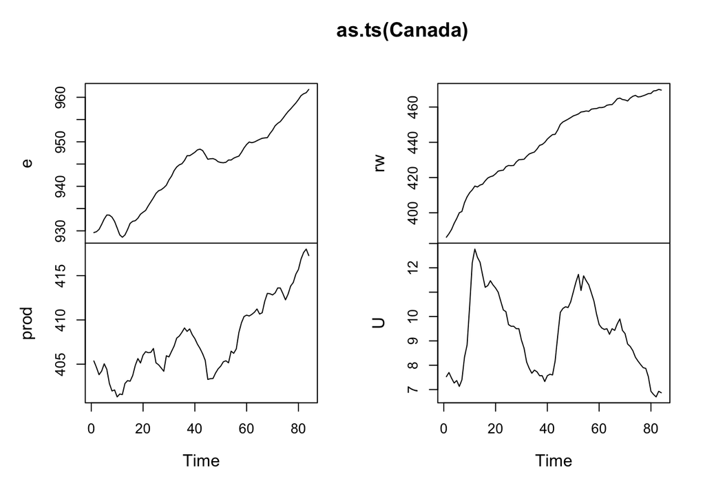

```r
rm(list = ls())

dat <- read.csv("/Users/waynezhang/Library/CloudStorage/OneDrive-UW-Madison/IOS-WIN/Econometric method/EMLearn/Topics/Undo/Time_Series/LectureNotes/T10-coint/Canada.csv")

Canada <- xts(dat[, 2:5], order.by = anytime::anydate(dat[, 1]))

plot(as.ts(Canada), nc = 2)
```

```r
# e: the logarithm of employment
# rw: the real wage
# prod: productivity
# U the unemployment rate
```

**Unit root test**

- type `none`: $\Delta y_t = \gamma \, y_{t-1} + e_t$
- type `drift`: $\Delta y_t = a_0 + \gamma \, y_{t-1} + e_t$
- type `trend`: $\Delta y_t = a_0 + \gamma * y_{t-1} + a_{2}t + e_t$

```r
# test cointegration
summary(ur.df(Canada[, "prod"], type = "trend", lags = 2))
```

```
##
## ###############################################
## # Augmented Dickey-Fuller Test Unit Root Test #
## ###############################################
##
## Test regression trend
##
##
## Call:
## lm(formula = z.diff ~ z.lag.1 + 1 + tt + z.diff.lag)
##
## Residuals:
##      Min       1Q   Median       3Q      Max
## -2.19924 -0.38994  0.04294  0.41914  1.71660
##
## Coefficients:
##              Estimate Std. Error t value Pr(>|t|)
## (Intercept) 30.415228  15.309403   1.987   0.0506 .
## z.lag.1     -0.075791   0.038134  -1.988   0.0505 .
## tt           0.013896   0.006422   2.164   0.0336 *
## z.diff.lag1  0.284866   0.114359   2.491   0.0149 *
## z.diff.lag2  0.080019   0.116090   0.689   0.4927
## ---
## Signif. codes:  0 '***' 0.001 '**' 0.01 '*' 0.05 '.' 0.1 ' ' 1
##
## Residual standard error: 0.6851 on 76 degrees of freedom
## Multiple R-squared:  0.1354, Adjusted R-squared:  0.08993
## F-statistic: 2.976 on 4 and 76 DF,  p-value: 0.02438
##
##
## Value of test-statistic is: -1.9875 2.3 2.3817
##
## Critical values for test statistics:
##       1pct  5pct 10pct
## tau3 -4.04 -3.45 -3.15
## phi2  6.50  4.88  4.16
## phi3  8.73  6.49  5.47
```

```r
summary(ur.df(diff(Canada[, "prod"])[-1, ], type = "drift", lags = 1))
```

```
##
## ###############################################
## # Augmented Dickey-Fuller Test Unit Root Test #
## ###############################################
##
## Test regression drift
##
##
## Call:
## lm(formula = z.diff ~ z.lag.1 + 1 + z.diff.lag)
##
## Residuals:
##      Min       1Q   Median       3Q      Max
## -2.05124 -0.39530  0.07819  0.41109  1.75129
##
## Coefficients:
##             Estimate Std. Error t value Pr(>|t|)
## (Intercept)  0.11534    0.08029   1.437    0.155
## z.lag.1     -0.68893    0.13350  -5.160 1.83e-06 ***
## z.diff.lag  -0.04274    0.11275  -0.379    0.706
## ---
## Signif. codes:  0 '***' 0.001 '**' 0.01 '*' 0.05 '.' 0.1 ' ' 1
##
## Residual standard error: 0.6971 on 78 degrees of freedom
## Multiple R-squared:  0.3615, Adjusted R-squared:  0.3451
## F-statistic: 22.08 on 2 and 78 DF,  p-value: 2.526e-08
##
##
## Value of test-statistic is: -5.1604 13.3184
##
## Critical values for test statistics:
##       1pct  5pct 10pct
## tau2 -3.51 -2.89 -2.58
## phi1  6.70  4.71  3.86
```

```r
summary(ur.df(Canada[, "e"], type = "trend", lags = 2))
```

```
##
## ###############################################
## # Augmented Dickey-Fuller Test Unit Root Test #
## ###############################################
##
## Test regression trend
##
##
## Call:
## lm(formula = z.diff ~ z.lag.1 + 1 + tt + z.diff.lag)
##
## Residuals:
##      Min       1Q   Median       3Q      Max
## -0.80266 -0.21963  0.01558  0.28686  0.73058
##
## Coefficients:
##              Estimate Std. Error t value Pr(>|t|)
## (Intercept) 34.571570  18.067987   1.913   0.0595 .
## z.lag.1     -0.037139   0.019458  -1.909   0.0601 .
## tt           0.014646   0.007209   2.032   0.0457 *
## z.diff.lag1  0.928088   0.107620   8.624 7.02e-13 ***
## z.diff.lag2 -0.251322   0.112917  -2.226   0.0290 *
## ---
## Signif. codes:  0 '***' 0.001 '**' 0.01 '*' 0.05 '.' 0.1 ' ' 1
##
## Residual standard error: 0.3849 on 76 degrees of freedom
## Multiple R-squared:  0.597,  Adjusted R-squared:  0.5758
## F-statistic: 28.15 on 4 and 76 DF,  p-value: 2.378e-14
##
##
## Value of test-statistic is: -1.9087 3.804 2.0874
##
## Critical values for test statistics:
##       1pct  5pct 10pct
## tau3 -4.04 -3.45 -3.15
## phi2  6.50  4.88  4.16
## phi3  8.73  6.49  5.47
```

```r
summary(ur.df(diff(Canada[, "e"])[-1, ], type = "drift", lags = 1))
```

```
##
## ###############################################
## # Augmented Dickey-Fuller Test Unit Root Test #
## ###############################################
##
## Test regression drift
##
##
## Call:
## lm(formula = z.diff ~ z.lag.1 + 1 + z.diff.lag)
##
## Residuals:
##      Min       1Q   Median       3Q      Max
## -0.91838 -0.24795 -0.02067  0.27069  0.74671
##
## Coefficients:
##             Estimate Std. Error t value Pr(>|t|)
## (Intercept)  0.14088    0.05309   2.653  0.00965 **
## z.lag.1     -0.35887    0.07956  -4.511 2.25e-05 ***
## z.diff.lag   0.31844    0.10790   2.951  0.00418 **
## ---
## Signif. codes:  0 '***' 0.001 '**' 0.01 '*' 0.05 '.' 0.1 ' ' 1
##
## Residual standard error: 0.3902 on 78 degrees of freedom
## Multiple R-squared:  0.2221, Adjusted R-squared:  0.2022
## F-statistic: 11.14 on 2 and 78 DF,  p-value: 5.568e-05
##
##
## Value of test-statistic is: -4.5107 10.1751
##
## Critical values for test statistics:
##       1pct  5pct 10pct
## tau2 -3.51 -2.89 -2.58
## phi1  6.70  4.71  3.86
```

```r
summary(ur.df(Canada[, "U"], type = "drift", lags = 1))
```

```
##
## ###############################################
## # Augmented Dickey-Fuller Test Unit Root Test #
## ###############################################
##
## Test regression drift
##
##
## Call:
## lm(formula = z.diff ~ z.lag.1 + 1 + z.diff.lag)
##
## Residuals:
##      Min       1Q   Median       3Q      Max
## -0.72032 -0.20517 -0.04822  0.16036  1.27685
##
## Coefficients:
##             Estimate Std. Error t value Pr(>|t|)
## (Intercept)  0.51542    0.23809   2.165   0.0334 *
## z.lag.1     -0.05561    0.02505  -2.220   0.0293 *
## z.diff.lag   0.59746    0.09111   6.557 5.18e-09 ***
## ---
## Signif. codes:  0 '***' 0.001 '**' 0.01 '*' 0.05 '.' 0.1 ' ' 1
##
## Residual standard error: 0.3539 on 79 degrees of freedom
## Multiple R-squared:  0.3598, Adjusted R-squared:  0.3436
## F-statistic:  22.2 on 2 and 79 DF,  p-value: 2.235e-08
##
##
## Value of test-statistic is: -2.2201 2.4762
##
## Critical values for test statistics:
##       1pct  5pct 10pct
## tau2 -3.51 -2.89 -2.58
## phi1  6.70  4.71  3.86
```

```r
summary(ur.df(diff(Canada[, "U"])[-1, ], type = "none", lags = 0))
```

```
##
## ###############################################
## # Augmented Dickey-Fuller Test Unit Root Test #
## ###############################################
##
## Test regression none
##
##
## Call:
## lm(formula = z.diff ~ z.lag.1 - 1)
##
## Residuals:
##      Min       1Q   Median       3Q      Max
## -0.84654 -0.22553 -0.05021  0.15609  1.31737
##
## Coefficients:
##         Estimate Std. Error t value Pr(>|t|)
## z.lag.1 -0.43474    0.09155  -4.749 8.71e-06 ***
## ---
## Signif. codes:  0 '***' 0.001 '**' 0.01 '*' 0.05 '.' 0.1 ' ' 1
##
## Residual standard error: 0.3603 on 81 degrees of freedom
## Multiple R-squared:  0.2178, Adjusted R-squared:  0.2081
## F-statistic: 22.55 on 1 and 81 DF,  p-value: 8.711e-06
##
##
## Value of test-statistic is: -4.7488
##
## Critical values for test statistics:
##      1pct  5pct 10pct
## tau1 -2.6 -1.95 -1.61
```

```r
summary(ur.df(Canada[, "rw"], type = "trend", lags = 4))
```

```
##
## ###############################################
## # Augmented Dickey-Fuller Test Unit Root Test #
## ###############################################
##
## Test regression trend
##
##
## Call:
## lm(formula = z.diff ~ z.lag.1 + 1 + tt + z.diff.lag)
##
## Residuals:
##      Min       1Q   Median       3Q      Max
## -2.56910 -0.49348 -0.05407  0.53899  2.67852
##
## Coefficients:
##             Estimate Std. Error t value Pr(>|t|)
## (Intercept) 20.17108    9.38785   2.149  0.03503 *
## z.lag.1     -0.04740    0.02305  -2.056  0.04342 *
## tt           0.03090    0.02045   1.511  0.13521
## z.diff.lag1  0.17198    0.10812   1.591  0.11608
## z.diff.lag2 -0.02622    0.10898  -0.241  0.81056
## z.diff.lag3 -0.08185    0.10919  -0.750  0.45594
## z.diff.lag4  0.32104    0.10758   2.984  0.00388 **
## ---
## Signif. codes:  0 '***' 0.001 '**' 0.01 '*' 0.05 '.' 0.1 ' ' 1
##
## Residual standard error: 0.8257 on 72 degrees of freedom
## Multiple R-squared:  0.3609, Adjusted R-squared:  0.3076
## F-statistic: 6.776 on 6 and 72 DF,  p-value: 1.009e-05
##
##
## Value of test-statistic is: -2.0558 3.2715 3.5018
##
## Critical values for test statistics:
##       1pct  5pct 10pct
## tau3 -4.04 -3.45 -3.15
## phi2  6.50  4.88  4.16
## phi3  8.73  6.49  5.47
```

```r
summary(ur.df(diff(Canada[, "rw"])[-1, ], type = "drift", lags = 3))
```

```
##
## ###############################################
## # Augmented Dickey-Fuller Test Unit Root Test #
## ###############################################
##
## Test regression drift
##
##
## Call:
## lm(formula = z.diff ~ z.lag.1 + 1 + z.diff.lag)
##
## Residuals:
##     Min      1Q  Median      3Q     Max
## -2.6181 -0.5280 -0.1168  0.5822  3.1184
##
## Coefficients:
##             Estimate Std. Error t value Pr(>|t|)
## (Intercept)   0.2648     0.1632   1.623 0.108929
## z.lag.1      -0.3456     0.1317  -2.624 0.010540 *
## z.diff.lag1  -0.4140     0.1330  -3.112 0.002641 **
## z.diff.lag2  -0.3790     0.1210  -3.132 0.002489 **
## z.diff.lag3  -0.3979     0.1036  -3.841 0.000257 ***
## ---
## Signif. codes:  0 '***' 0.001 '**' 0.01 '*' 0.05 '.' 0.1 ' ' 1
##
## Residual standard error: 0.8532 on 74 degrees of freedom
## Multiple R-squared:  0.4545, Adjusted R-squared:  0.425
## F-statistic: 15.41 on 4 and 74 DF,  p-value: 3.255e-09
##
##
## Value of test-statistic is: -2.6244 3.8004
##
## Critical values for test statistics:
##       1pct  5pct 10pct
## tau2 -3.51 -2.89 -2.58
## phi1  6.70  4.71  3.86
```

```r
summary(ur.df(diff(Canada[, "rw"])[-1, ], type = "drift", lags = 0))
```

```
##
## ###############################################
## # Augmented Dickey-Fuller Test Unit Root Test #
## ###############################################
##
## Test regression drift
##
##
## Call:
## lm(formula = z.diff ~ z.lag.1 + 1)
##
## Residuals:
##     Min      1Q  Median      3Q     Max
## -1.9840 -0.5713 -0.1145  0.5992  4.1143
##
## Coefficients:
##             Estimate Std. Error t value Pr(>|t|)
## (Intercept)   0.5529     0.1476   3.747 0.000336 ***
## z.lag.1      -0.5687     0.1015  -5.603 2.89e-07 ***
## ---
## Signif. codes:  0 '***' 0.001 '**' 0.01 '*' 0.05 '.' 0.1 ' ' 1
##
## Residual standard error: 0.9493 on 80 degrees of freedom
## Multiple R-squared:  0.2818, Adjusted R-squared:  0.2728
## F-statistic: 31.39 on 1 and 80 DF,  p-value: 2.892e-07
##
##
## Value of test-statistic is: -5.6027 15.7327
##
## Critical values for test statistics:
##       1pct  5pct 10pct
## tau2 -3.51 -2.89 -2.58
## phi1  6.70  4.71  3.86
```

### 0.4.1 Estimate the model

```r
VARselect(Canada, lag.max = 8, type = "both")
```

```
## $selection
## AIC(n)  HQ(n)  SC(n) FPE(n)
##      3      2      1      3
##
## $criteria
##                   1            2            3            4            5
## AIC(n) -6.272579094 -6.636669729 -6.771176832 -6.634609161 -6.398132194
## HQ(n)  -5.978429479 -6.146420370 -6.084827731 -5.752160316 -5.319583606
## SC(n)  -5.536558039 -5.409967971 -5.053794371 -4.426545996 -3.699388326
## FPE(n)  0.001889842  0.001319462  0.001166019  0.001363175  0.001782055
##                   6            7           8
## AIC(n) -6.307704732 -6.070727128 -6.06159666
## HQ(n)  -5.033056400 -4.599979053 -4.39474884
## SC(n)  -3.118280161 -2.390621854 -1.89081068
## FPE(n)  0.002044202  0.002768551  0.00306012
```

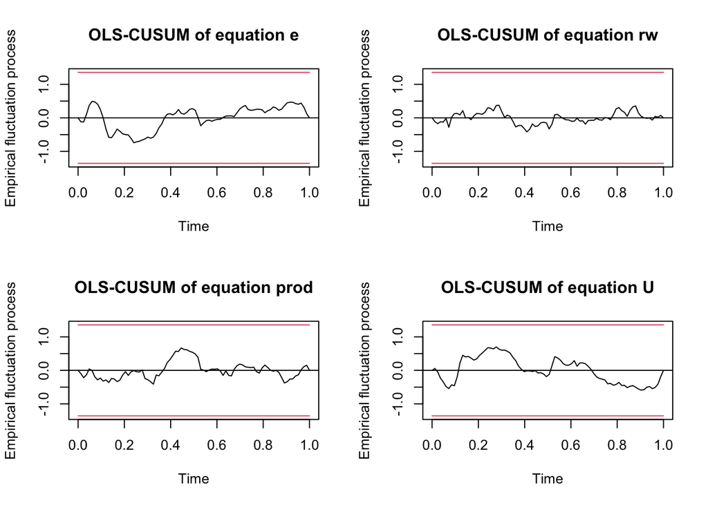

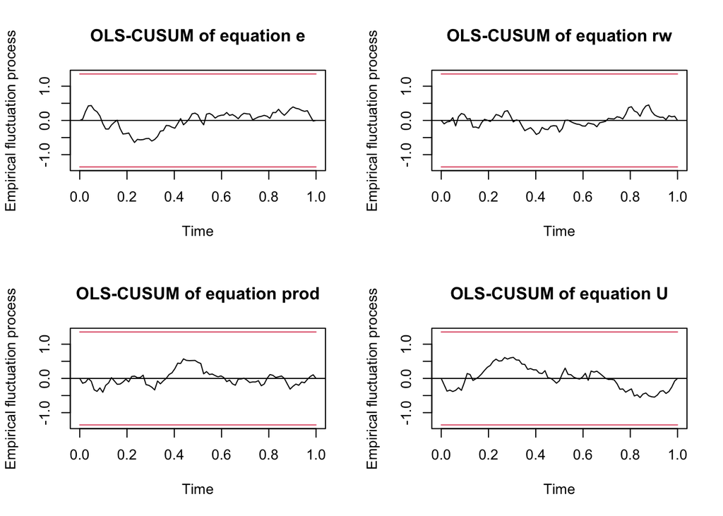

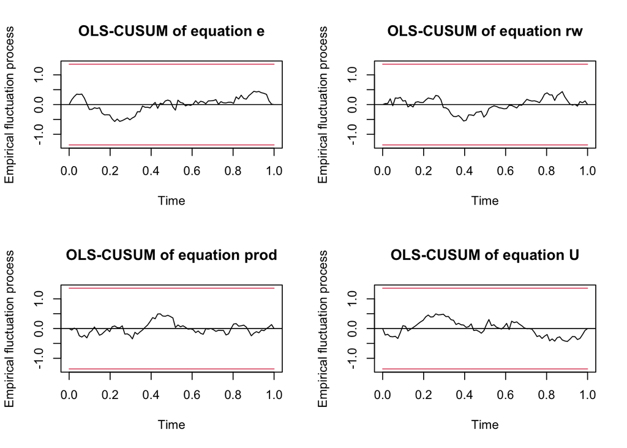

```r
p1ct <- VAR(Canada, p = 1, type = "both")
p2ct <- VAR(Canada, p = 2, type = "both")
p3ct <- VAR(Canada, p = 3, type = "both")

# test
for(i in c("p1ct", "p2ct", "p3ct")){
    serial.test(get(i), lags.pt = 16, type = "PT.asymptotic")
    serial.test(get(i), lags.pt = 16, type = "PT.adjusted")
    normality.test(get(i))
    arch.test(get(i), lags.multi = 5)
    plot(stability(get(i)), nc = 2)

}
```